# Cancer Dependency Explorer

This pipeline integrates CRISPR dependency with lineage, expression, copy number and damaging somatic mutations from **DepMap Public 26Q1**. Please note, throughout the report, more negative Chronos scores indicate that knocking out the target gene has a stronger effect on cell fitness. This is interpreted as stronger dependency on the target gene selected, in this case: **EGFR**.

This report addresses the following question:

**Which molecular features predict dependency on EGFR across cancer cell models?**

The overall report narrative is structured as follows:

- What does dependency on my gene look like?
- Does it vary by cancer type?
- Which molecular features are associated with it individually?
- Which of those features still provide information when considered together?

This analysis included **NF1 damaging mutation**, **PTEN damaging mutation**, **MET copy number**, **ERBB2 copy number** as user-specified prior hypotheses. A prior is a biological hypothesis chosen before the automatic search: it is carried into the combined model as long as it passes the basic data-eligibility checks. This ensures that the hypothesis is tested alongside the automatically discovered features, but does not assume that it will be statistically significant or biologically validated.

# Data quality

Pre-analysis data-quality checks

| check | passed | detail |
| --- | --- | --- |
| Target in CRISPR matrix | TRUE | EGFR |
| Unique ModelID after multiomic joins | TRUE | 1208 |
| At least 50 dependency observations | TRUE | 1208 |
| At least 50 models with lineage annotation | TRUE | 1208 |
| Expression has nonzero variance | TRUE | SD 2.345 |
| Copy number has nonzero variance | TRUE | SD 2.451 |

6 of 6 checks passed (a failed check is retained in this report but critical failures stop the workflow ahead of modelling).

# Dependency distribution

The first exploratory question is whether dependency on EGFR is observed in a subset of DepMap pancancer cell line models or is a broadly distributed dependency. The distribution of Chronos scores across all models is shown below:

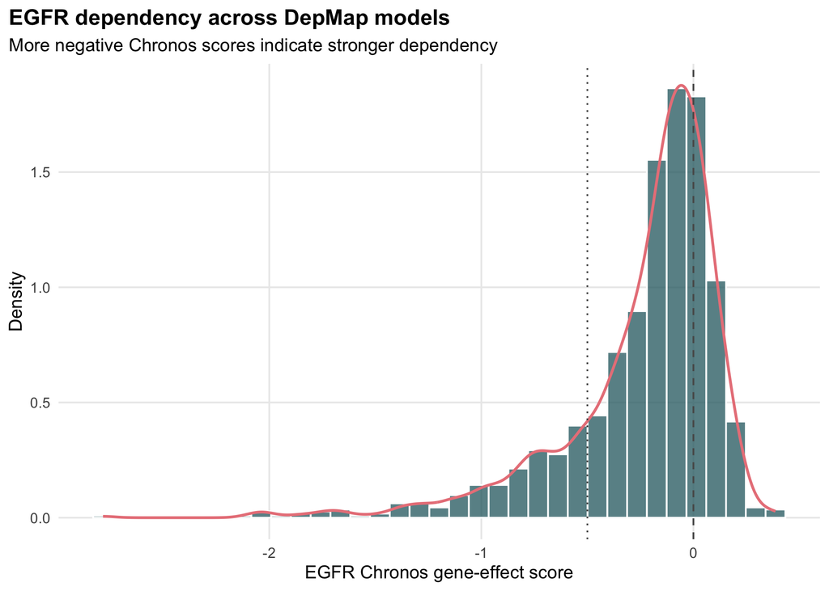

Across 1208 models, the median EGFR Chronos score was -0.13. The proportion of cell lines with Chronos scores below -0.5 (what is generally considered as *strong dependency*) was 17.5%.

# Lineage specificity

Cancer types can differ in which genes they require for survival. Before examining individual molecular biomarkers, the question is whether EGFR dependency is concentrated in particular cancer lineages. The plot shows the size and direction of these differences, while the global Kruskal–Wallis test evaluates if there is evidence of an overall lineage association.

The global comparison found evidence that **EGFR dependency differs across cancer lineages** (Kruskal–Wallis P = 1.4e-40). This means that at least one lineage has a different dependency distribution; the comparisons below show which lineages may contribute to the pattern.

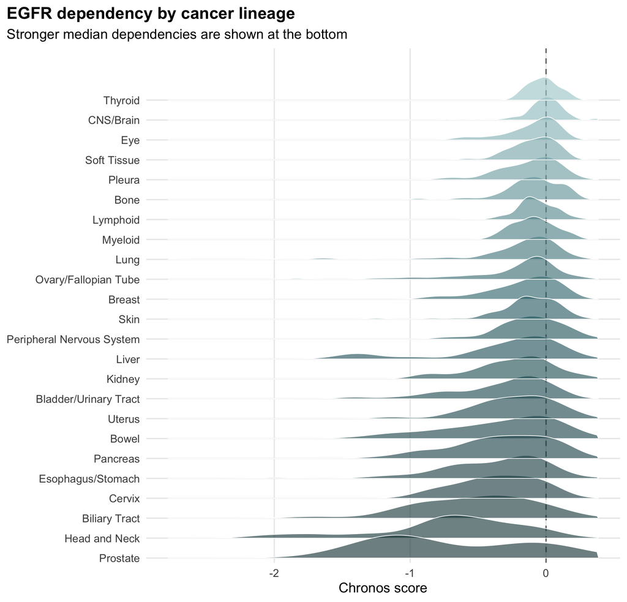

To identify which lineages may contribute to this variation, each lineage was compared with all other eligible models combined. The table reports the leading lineage-versus-rest results; negative median differences indicate stronger dependency in that lineage, whereas positive differences indicate weaker dependency.

Leading lineage associations

|  | lineage | n | mean | median | rest_n | rest_median | median_difference | p_value | fdr |
| --- | --- | --- | --- | --- | --- | --- | --- | --- | --- |
| 2 | Head and Neck | 77 | -0.718 | -0.668 | 1116 | -0.118 | -0.551 | 0.000 | 0.000 |
| 24 | CNS/Brain | 91 | -0.011 | -0.004 | 1102 | -0.146 | 0.141 | 0.000 | 0.000 |
| 3 | Biliary Tract | 34 | -0.527 | -0.467 | 1159 | -0.127 | -0.340 | 0.000 | 0.000 |
| 5 | Esophagus/Stomach | 69 | -0.390 | -0.307 | 1124 | -0.125 | -0.182 | 0.000 | 0.000 |
| 18 | Lymphoid | 96 | -0.073 | -0.089 | 1097 | -0.137 | 0.048 | 0.000 | 0.000 |
| 1 | Prostate | 10 | -0.703 | -0.973 | 1183 | -0.128 | -0.845 | 0.009 | 0.030 |
| 20 | Bone | 58 | -0.100 | -0.076 | 1135 | -0.132 | 0.056 | 0.008 | 0.030 |
| 21 | Soft Tissue | 49 | -0.090 | -0.061 | 1144 | -0.133 | 0.072 | 0.011 | 0.033 |
| 4 | Cervix | 18 | -0.360 | -0.341 | 1175 | -0.128 | -0.213 | 0.019 | 0.046 |
| 6 | Pancreas | 48 | -0.332 | -0.298 | 1145 | -0.128 | -0.170 | 0.017 | 0.046 |

**Head and Neck** (median difference -0.551; FDR 2.4e-19) and **Biliary Tract** (median difference -0.34; FDR 2.8e-05) contributed to the lineage association through more-negative dependency scores than the remaining models, indicating stronger **EGFR dependency** in those cancer contexts. Conversely, **CNS/Brain** (median difference +0.141; FDR 3.4e-13) and **Lymphoid** (median difference +0.0483; FDR 3.1e-04) contributed through more-positive scores, indicating weaker **EGFR dependency** relative to the remaining models. These results show that lineage captures systematic differences in dependency and could confound molecular associations.

Note: Lineage associations may reflect molecular features that are enriched in particular histologies. For example, an apparent mutation–EGFR dependency association could partly arise because the mutation is common in a lineage that is already more dependent on EGFR. The multivariable linear regression therefore adjusts for lineage to reduce this potential confounding when estimating molecular associations.

# Target expression and copy number

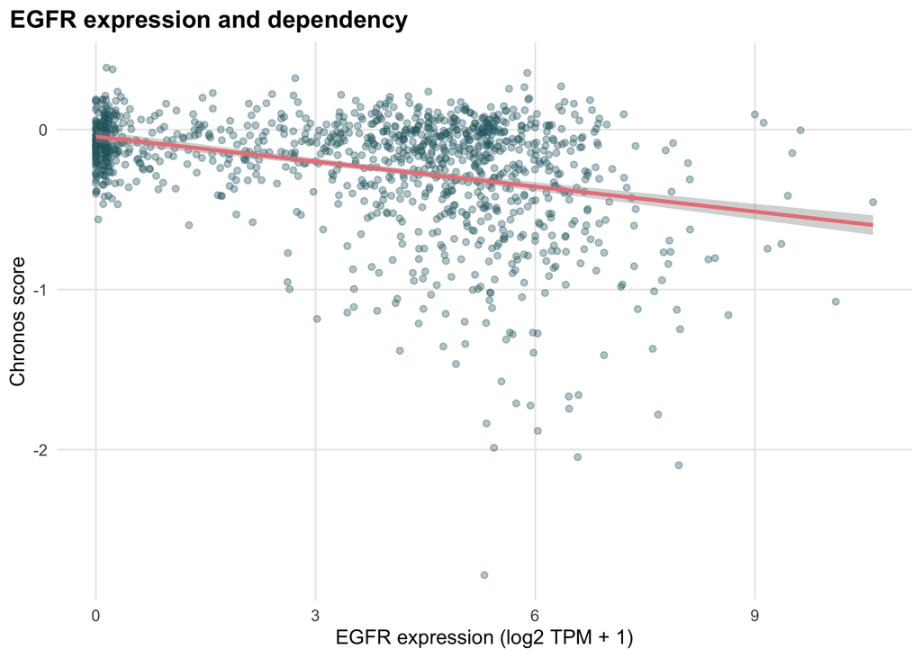

EGFR expression showed Spearman rho -0.285 (P = 9.4e-23); EGFR copy number showed Spearman rho -0.136 (P = 6.6e-05).

No target expression or copy-number correlation was both statistically significant and at least moderate in magnitude (|rho| >= 0.30). Although EGFR expression and EGFR copy number showed statistically detectable correlations, their small effect sizes provide limited evidence that either feature alone strongly distinguishes `EGFR`-dependent models.

# Genomic associations

Having assessed lineage and the target’s own expression and copy number, the following sections compute associations with damaging mutations and copy-number measurements across the whole genome.

The aim is to identify molecular features that flag models with stronger or weaker EGFR dependency and to nominate a small candidate set for the multivariable linear regression. These are one-feature-at-a-time screens, so correlated or lineage-associated findings are evaluated together later.

### Damaging mutations

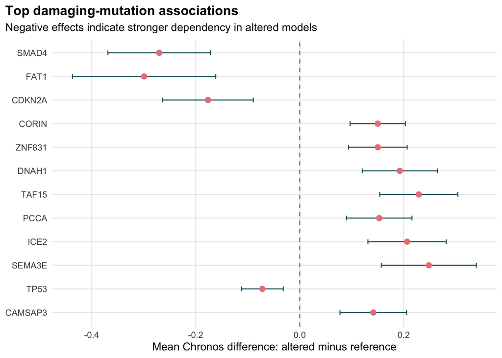

The leading mutation association was **SMAD4** (mean Chronos difference, altered vs reference/wild type: -0.27, FDR 0.002) (a negative difference denotes stronger `EGFR` dependency in defective/altered models).

The plot summarises the leading mutation associations. Expand the section below to inspect altered and reference group sizes, mean dependency scores and statistical results.

**View detailed mutation results**

Top damaging-mutation associations

| gene | altered_n | reference_n | altered_mean_dependency | reference_mean_dependency | effect | std_error | conf_low | conf_high | p_value | eligible | fdr |
| --- | --- | --- | --- | --- | --- | --- | --- | --- | --- | --- | --- |
| SMAD4 | 60 | 1148 | -0.494 | -0.224 | -0.270 | 0.050 | -0.369 | -0.172 | 0 | TRUE | 0.002 |
| FAT1 | 60 | 1148 | -0.522 | -0.222 | -0.299 | 0.070 | -0.437 | -0.162 | 0 | TRUE | 0.027 |
| CDKN2A | 140 | 1068 | -0.393 | -0.217 | -0.177 | 0.044 | -0.264 | -0.089 | 0 | TRUE | 0.027 |
| CORIN | 10 | 1198 | -0.089 | -0.239 | 0.150 | 0.027 | 0.097 | 0.203 | 0 | TRUE | 0.027 |
| ZNF831 | 12 | 1196 | -0.089 | -0.239 | 0.150 | 0.029 | 0.094 | 0.206 | 0 | TRUE | 0.027 |
| DNAH1 | 14 | 1194 | -0.047 | -0.240 | 0.192 | 0.037 | 0.120 | 0.265 | 0 | TRUE | 0.027 |
| TAF15 | 10 | 1198 | -0.010 | -0.239 | 0.229 | 0.038 | 0.154 | 0.304 | 0 | TRUE | 0.027 |
| PCCA | 13 | 1195 | -0.086 | -0.239 | 0.153 | 0.032 | 0.090 | 0.216 | 0 | TRUE | 0.044 |
| ICE2 | 10 | 1198 | -0.033 | -0.239 | 0.206 | 0.038 | 0.131 | 0.282 | 0 | TRUE | 0.044 |
| SEMA3E | 11 | 1197 | 0.009 | -0.240 | 0.248 | 0.047 | 0.157 | 0.340 | 0 | TRUE | 0.044 |

### Copy number

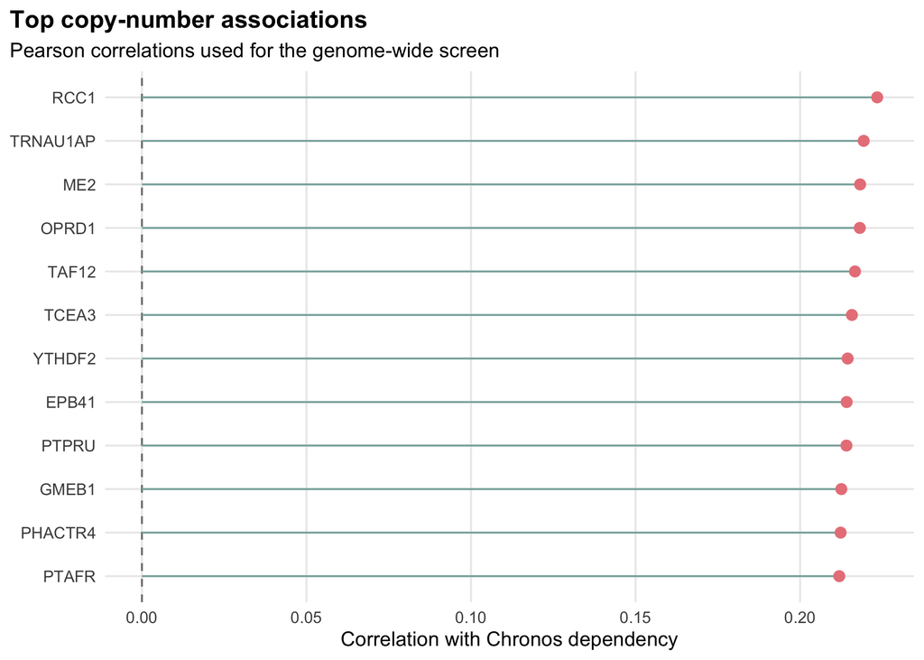

The leading copy-number association was **RCC1** (correlation 0.223, FDR 5.1e-07). No genome-wide copy-number correlation was both significant at 5% FDR and at least moderate in magnitude (|r| >= 0.30). Thus, this screen found no substantial copy-number association with either stronger or weaker `EGFR` dependency.

# Multivariable linear regression

The earlier sections examined lineage, expression, copy number and mutations separately. We now combine these results in an ordinary multivariable linear regression to identify which molecular features still distinguish more- from less-EGFR-dependent models after accounting for the others. Cancer lineage is included to account for differences between cancer types, but is omitted from the plot so the molecular results remain easy to read.

The regression does not include every feature from the genome-wide screens. It contains:

- **Target expression and target copy number**, which are always included as broadly measured features of the selected target.
- **Cancer lineage**, which is included for adjustment but omitted from the molecular plot.
- Any eligible biomarkers supplied in the optional hypothesis file.
- Up to two automatic mutation and two automatic copy-number discoveries that pass their screening FDR and redundancy filters.

Automatic mutation discoveries require at least 10 altered and 10 reference models. Automatic copy-number discoveries require at least 80% coverage and nonzero variance. Both must pass FDR < 0.05, and an automatic feature is skipped if its absolute correlation with a retained predictor is at least 0.80.

**Target-gene mutation is not automatically included in the regression.** The pipeline first compares target dependency between cell lines with and without a damaging mutation in the target itself. If enough cell lines are available and this comparison passes the automatic-selection rules, target mutation is included. It may also be included as a user-specified prior, provided there are at least 10 altered and 10 reference models.

Points to the left indicate stronger dependency and points to the right indicate weaker dependency. Features are ordered by their model FDR; pink points pass the 5% FDR threshold. The bars show HC3-adjusted 95% confidence intervals.

Each point is a coefficient from the ordinary linear regression: the estimated change in the EGFR Chronos score associated with that feature while the other features and lineage are held constant. For expression and copy number, 1 SD higher means one standard deviation above another model; damaging mutations compare altered with reference models. A confidence interval crossing zero means the direction remains uncertain.

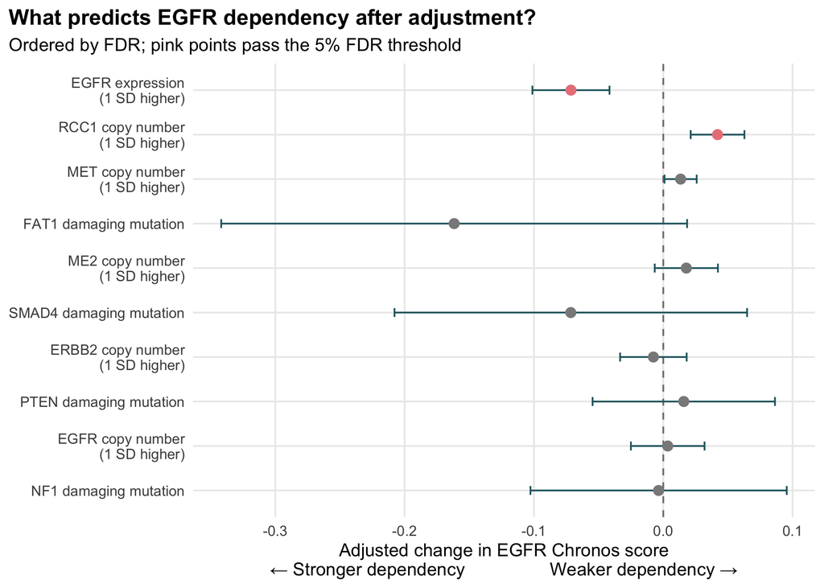

The ordinary linear regression combined lineage and molecular data from **852 cell models**. Together, these features accounted for **20.8%** of the observed differences in `EGFR` dependency. When tested on cell models left out during fitting, its overall prediction error was **0.312 Chronos units**. Its held-out predictions accounted for **16.2%** of the differences between those models. The coefficients and predictions come from the ordinary linear regression. HC3 is not a different model: it is applied after fitting and changes only the standard errors, confidence intervals and P values, from which FDR is calculated. We’re using this adjustment of confidence intervals because it gives extra weight to prediction errors from cell lines with unusual predictor combinations when calculating uncertainty, helping prevent a few influential models from making an association appear more precise than it is.

**2 of 10** plotted molecular features passed the 5% FDR threshold: **EGFR expression (for a 1 SD increase)** and **RCC1 copy number (for a 1 SD increase)**. The strongest adjusted molecular association was **EGFR expression (for a 1 SD increase)** (coefficient -0.0714; 95% CI -0.101 to -0.0416), corresponding to stronger dependency as the feature increases or is present.

Expand the section below to inspect the exact numbers behind the plot, ordered from lowest to highest FDR. Note also the estimate, whether it is positive or negative, to understand the adjusted change (effect, direction) on the dependency. The full table also includes the intercept and lineage adjustment terms omitted from the figure.

**View full linear-regression results**

Full linear-regression results, ordered by FDR

|  | term | estimate | std_error | statistic | p_value | conf_low | conf_high | label | fdr |
| --- | --- | --- | --- | --- | --- | --- | --- | --- | --- |
| 2 | z_target_expression | -0.071 | 0.015 | -4.699 | 0.000 | -0.101 | -0.042 | EGFR expression (for a 1 SD increase) | 0.000 |
| 1 | (Intercept) | -0.171 | 0.039 | -4.423 | 0.000 | -0.246 | -0.095 | (Intercept) | 0.000 |
| 10 | z_copy_number__RCC1 | 0.042 | 0.011 | 3.965 | 0.000 | 0.021 | 0.063 | RCC1 copy number (for a 1 SD increase) | 0.001 |
| 19 | lineage_modelHead and Neck | -0.299 | 0.084 | -3.557 | 0.000 | -0.464 | -0.134 | Lineage: Head and Neck vs Lung | 0.003 |
| 17 | lineage_modelCNS/Brain | 0.159 | 0.046 | 3.445 | 0.001 | 0.069 | 0.250 | Lineage: CNS/Brain vs Lung | 0.004 |
| 6 | z_copy_number__MET | 0.013 | 0.006 | 2.116 | 0.035 | 0.001 | 0.026 | MET copy number (for a 1 SD increase) | 0.179 |
| 9 | mutation__FAT1 | -0.162 | 0.092 | -1.762 | 0.078 | -0.342 | 0.018 | FAT1 damaging mutation | 0.309 |
| 12 | lineage_modelBiliary Tract | -0.305 | 0.174 | -1.754 | 0.080 | -0.646 | 0.036 | Lineage: Biliary Tract vs Lung | 0.309 |
| 18 | lineage_modelEsophagus/Stomach | -0.127 | 0.076 | -1.666 | 0.096 | -0.276 | 0.023 | Lineage: Esophagus/Stomach vs Lung | 0.331 |
| 15 | lineage_modelBowel | -0.114 | 0.071 | -1.595 | 0.111 | -0.254 | 0.026 | Lineage: Bowel vs Lung | 0.344 |
| 11 | z_copy_number__ME2 | 0.018 | 0.012 | 1.433 | 0.152 | -0.007 | 0.042 | ME2 copy number (for a 1 SD increase) | 0.377 |
| 24 | lineage_modelOther | -0.095 | 0.067 | -1.420 | 0.156 | -0.226 | 0.036 | Lineage: Other vs Lung | 0.377 |
| 23 | lineage_modelMyeloid | -0.068 | 0.048 | -1.413 | 0.158 | -0.163 | 0.027 | Lineage: Myeloid vs Lung | 0.377 |
| 28 | lineage_modelPleura | 0.089 | 0.070 | 1.268 | 0.205 | -0.049 | 0.226 | Lineage: Pleura vs Lung | 0.454 |
| 20 | lineage_modelKidney | -0.081 | 0.075 | -1.081 | 0.280 | -0.229 | 0.066 | Lineage: Kidney vs Lung | 0.498 |
| 22 | lineage_modelLymphoid | -0.048 | 0.045 | -1.071 | 0.284 | -0.137 | 0.040 | Lineage: Lymphoid vs Lung | 0.498 |
| 8 | mutation__SMAD4 | -0.072 | 0.069 | -1.030 | 0.303 | -0.208 | 0.065 | SMAD4 damaging mutation | 0.498 |
| 30 | lineage_modelSoft Tissue | 0.050 | 0.049 | 1.027 | 0.305 | -0.046 | 0.146 | Lineage: Soft Tissue vs Lung | 0.498 |
| 16 | lineage_modelBreast | 0.053 | 0.053 | 0.999 | 0.318 | -0.051 | 0.156 | Lineage: Breast vs Lung | 0.498 |
| 31 | lineage_modelUterus | -0.075 | 0.075 | -0.993 | 0.321 | -0.223 | 0.073 | Lineage: Uterus vs Lung | 0.498 |
| 21 | lineage_modelLiver | -0.088 | 0.097 | -0.908 | 0.364 | -0.279 | 0.102 | Lineage: Liver vs Lung | 0.537 |
| 14 | lineage_modelBone | -0.045 | 0.052 | -0.869 | 0.385 | -0.147 | 0.057 | Lineage: Bone vs Lung | 0.543 |
| 25 | lineage_modelOvary/Fallopian Tube | -0.063 | 0.076 | -0.826 | 0.409 | -0.212 | 0.087 | Lineage: Ovary/Fallopian Tube vs Lung | 0.551 |
| 29 | lineage_modelSkin | -0.031 | 0.053 | -0.593 | 0.553 | -0.135 | 0.072 | Lineage: Skin vs Lung | 0.695 |
| 7 | z_copy_number__ERBB2 | -0.008 | 0.013 | -0.583 | 0.560 | -0.033 | 0.018 | ERBB2 copy number (for a 1 SD increase) | 0.695 |
| 13 | lineage_modelBladder/Urinary Tract | -0.044 | 0.097 | -0.455 | 0.649 | -0.235 | 0.146 | Lineage: Bladder/Urinary Tract vs Lung | 0.757 |
| 5 | mutation__PTEN | 0.016 | 0.036 | 0.441 | 0.659 | -0.055 | 0.086 | PTEN damaging mutation | 0.757 |
| 27 | lineage_modelPeripheral Nervous System | 0.021 | 0.053 | 0.390 | 0.697 | -0.083 | 0.125 | Lineage: Peripheral Nervous System vs Lung | 0.771 |
| 3 | z_target_copy_number | 0.003 | 0.015 | 0.238 | 0.812 | -0.025 | 0.032 | EGFR copy number (for a 1 SD increase) | 0.868 |
| 26 | lineage_modelPancreas | -0.013 | 0.080 | -0.159 | 0.874 | -0.169 | 0.144 | Lineage: Pancreas vs Lung | 0.903 |
| 4 | mutation__NF1 | -0.004 | 0.050 | -0.071 | 0.943 | -0.103 | 0.096 | NF1 damaging mutation | 0.943 |

# Conclusion, interpretation and limitations

This report asked which molecular features predict dependency on **EGFR** across cancer cell models. It first described the dependency distribution and cancer-lineage pattern, then screened target expression, target copy number, damaging mutations and genome-wide copy number individually. The final ordinary linear regression brought the candidate features together with lineage to ask which features still contributed information after their potential confounding was considered.

The ordinary linear regression estimates an adjusted association for each feature while holding the others constant. Continuous measurements were placed on a common scale, so their coefficients describe a one-standard-deviation increase. HC3 is then applied only to the uncertainty calculation; it does not refit the regression or change its coefficients and predictions. HC3 gives extra weight to prediction errors from cell lines with unusual predictor combinations when calculating standard errors, helping prevent a small number of influential models from making an association appear too precise.

Specifically:

Across **1208 pancancer models**, the median `EGFR` Chronos score was **-0.13**, and **17.5%** of models had a score below -0.5. Dependency varied across cancer lineages, with **Head and Neck** and **Biliary Tract** among the contexts showing a stronger dependency than models from remaining lineages.

After adjustment and FDR correction, higher **EGFR expression** was associated with **stronger EGFR dependency** (-0.0714 Chronos units per 1 SD increase; FDR 9.5e-05); higher **RCC1 copy number** was associated with **weaker EGFR dependency** (0.042 Chronos units per 1 SD increase; FDR 8.2e-04).

These results provide a prioritisation map. For example, FDR-supported features could be tested as candidate biomarkers in independent, lineage-balanced models, while lineage findings can guide the cancer contexts included in validation experiments. Copy-number findings should also be tested to determine whether they represent the named gene or a broader chromosomal event. A useful next experiment is to ask whether the nominated feature reproducibly separates models with stronger and weaker EGFR dependency and whether the relationship persists with an independent genetic or pharmacological perturbation.

# Reproducibility

The pipeline saves summary tables, figures and the completed report locally. Raw DepMap matrices and cell-line-level intermediate files remain excluded from version control; users must obtain the source data from DepMap (see README) and regenerate the intermediate files by running the pipeline to obtain a copy of this report with a new target gene.